# Introduction to Data Analysis with Python

[figure not shown]

# Objectives

- Handle linear algebra using `numpy`
- Handle tabular data with `pandas`

# The Python scientific stack: SciPy

Python Main Data Libraries

NumPy: Base N-dimensional array package. Algebra lineal y calculo numérico muy rapido

SciPy library: Fundamental library for scientific computing

Matplotlib: Comprehensive 2D Plotting. Grafica y dibuja tablas

IPython: Enhanced Interactive Console. Interprete de Python. Tiene mejoras sobre python (autocompletado, colores, etc)

Sympy: Symbolic mathematics. Mattematica simolica (tiene aproximacion numerica y simolica)

pandas: Data structures & analysis. Es una ampliacion de Numpy incorpora semantica de tablas con filtros, tec

## `matplotlib`

```python
import pandas as pd
import numpy as np
import matplotlib.pyplot as plt

plt.style.use('ggplot') # para cambiar los estilos. Estos son mas chulos

%matplotlib inline # para ver los graficos de forma online y pasar a archivos
```

```python
help(plt.plot)
```

[output not shown]

[output cut: 121 more lines]

[output not shown]

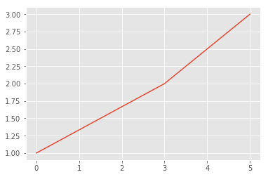

```python
plt.plot([0, 3, 5], [1, 2, 3]) # tienen que tener los mismos elementos, se unen los primeros, los segundos...
plt.show()
```

```python
np.pi # variable 3,14
```

```
3.141592653589793
```

```python
np.e
```

```
2.718281828459045
```

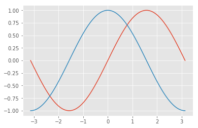

```python
X = np.linspace(-np.pi, np.pi, 100) # Muestra la linea comienzo, final y 100 es el numero de  puntos
S = np.sin(X)
C = np.cos(X)

plt.plot(X, S)
plt.plot(X, C)
plt.show()
```

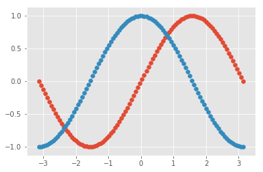

```python
plt.scatter(X, S)  # Muestra consecucion de los puntos.se le pueden poner colores y mas caracteristicas de las graficas
plt.scatter(X, C)
plt.show()
```

## `numpy`

Base N-dimensional array package. We can use it to perform array operations. Its arrays are typed and can have any shape and dimension we want.

```python
np.version.version
```

```
'1.13.1'
```

```python
a_list = [1, 2, 3.4, 6, 8, 2, 42]

a = np.array(a_list)       # se pasa a array para poder trabajar con la lista
a.dtype
```

```
dtype('float64')
```

```python
a.shape       # nº de elementos en la dimension de a
```

```
(7,)
```

```python
a.ndim       # nº de Dimensiones
```

```
1
```

```python
b1_list = ([5,6,7,8,9], [2,3,4,5,5], [3,4,6,7])
b1 = np.array(b1_list)                             # array de listas
b1
```

```
array([list([5, 6, 7, 8, 9]), list([2, 3, 4, 5, 5]), list([3, 4, 6, 7])], dtype=object)
```

```python
np.array([[1,2,3],[4,5,6],[7,8,9]])           # array de elementos
```

```
array([[1, 2, 3],
       [4, 5, 6],
       [7, 8, 9]])
```

```python
a2 = np.array([[1,2,3],[4,5,6],[7,8,9], [10, 11, 12], [13, 14, 15]])
a2
```

```
array([[ 1,  2,  3],
       [ 4,  5,  6],
       [ 7,  8,  9],
       [10, 11, 12],
       [13, 14, 15]])
```

```python
a2.shape
```

```
(5, 3)
```

```python
np.array([[1,2,3],[4,5,6],[7,9]])
```

```
array([list([1, 2, 3]), list([4, 5, 6]), list([7, 9])], dtype=object)
```

```python
a2?   # con la ? despues del objeto da informacion sobre el tipo, los elementos, etc.
```

There are a number of convenience functions to create particular special arrays.

```python
print(np.eye(3))         # genera un array de 2 D con Number of rows in the output.
print(np.ones([2,3]))    # devuelve una nueva matriz de forma y tipo dados, llena de unos.
print(np.zeros([3,3]))   # devuelve una nueva matriz de forma y tipo dados, llena de ceros.
print(np.zeros_like(a2)) # devuelve una nueva matriz  parecida a una determinada
```

```
[[ 1.  0.  0.]
 [ 0.  1.  0.]
 [ 0.  0.  1.]]
[[ 1.  1.  1.]
 [ 1.  1.  1.]]
[[ 0.  0.  0.]
 [ 0.  0.  0.]
 [ 0.  0.  0.]]
[[0 0 0]
 [0 0 0]
 [0 0 0]
 [0 0 0]
 [0 0 0]]
```

```python
np.arange(9)
```

```
array([0, 1, 2, 3, 4, 5, 6, 7, 8])
```

```python
np.arange(4, 100, 5)    # valores desde 4 a 100 contados de 5 en 5
```

```
array([ 4,  9, 14, 19, 24, 29, 34, 39, 44, 49, 54, 59, 64, 69, 74, 79, 84,
       89, 94, 99])
```

```python
np.linspace(4, 12, 14)   #Devuelve números espaciados uniformemente durante un intervalo especificado.
```

```
array([  4.        ,   4.61538462,   5.23076923,   5.84615385,
         6.46153846,   7.07692308,   7.69230769,   8.30769231,
         8.92307692,   9.53846154,  10.15384615,  10.76923077,
        11.38461538,  12.        ])
```

We are going to use these a lot to create example data. With reshape, we can turn them into any shape we want.

```python
np.arange(20).reshape(4,5)  # crea un array de 0-20 y lo formatatea a una matriz de 4 lineas y 5 columnas
```

```
array([[ 0,  1,  2,  3,  4],
       [ 5,  6,  7,  8,  9],
       [10, 11, 12, 13, 14],
       [15, 16, 17, 18, 19]])
```

And arrays of random variables.

```python
np.random.rand(10)  # distribuye uniformemente y aleatoriamente
```

```
array([ 0.6461707 ,  0.89008997,  0.53429659,  0.8005108 ,  0.56308842,
        0.21660654,  0.69346173,  0.33735654,  0.50568979,  0.12574936])
```

```python
np.random.randn(10) #distribución "normal" (gaussiana) univariante de media 0 y varianza
```

```
array([ 1.25832767, -1.04492948,  1.06151395,  0.78708413, -2.1983744 ,
       -0.14979823,  0.69227648,  1.49818732,  0.88953152,  0.79529443])
```

A central advantage of numpy over regular python lists, apart from the many convenience functions, is speed.

```python
import math
```

```python
%%timeit                # Comprueba el tiempo de la ejecucion o salida de la sentencia siguiente

[x ** 2 for x in range(1000000)]
```

```
274 ms ± 4.01 ms per loop (mean ± std. dev. of 7 runs, 1 loop each)
```

```python
%%timeit

np.arange(1000000) ** 2
```

```
2.29 ms ± 108 µs per loop (mean ± std. dev. of 7 runs, 100 loops each)
```

Exercise

Now, plot it as either a cloud of points or a line.

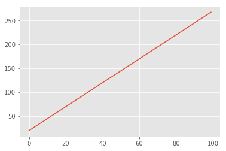

```python
X = np.arange(100)
A = 2.5
B= 20
Y = A * X + B

plt.plot(X, Y)
plt.show()
```

#### Exercise

Represent the logistic, or sigmoid, function between -20 and 20. Remember its formula is:

$$\displaystyle S(x)={\frac {1}{1+e^{-x}}}={\frac {e^{x}}{e^{x}+1}}$$

*Hint*: you will need an X and a Y to plot against it.

*Hint*: check out the function np.exp

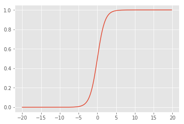

```python
X = np.arange(-20, 20, .2)    # comienzo, final y saltos de 0,2
S = 1 / (1 + np.exp(-X))

plt.plot(X, S)
plt.show()
```

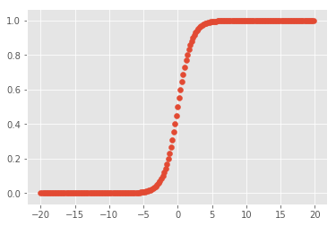

```python
X = np.arange(-20, 20, .2)
S = 1 / (1 + np.exp(-X))

plt.scatter(X, S)
plt.show()
```

We can also create a random set of points

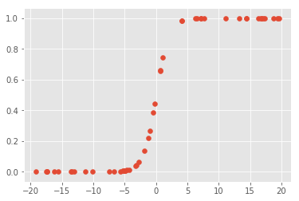

```python
X = np.random.rand(50) * 40 - 20
S = 1 / (1 + np.exp(-X))

plt.scatter(X, S)
plt.show()
```

However, if we don't sort them prior to plotting lines, the results will be off since plt.plot draws the lines from point to point in the order it gets them in the input arrays.

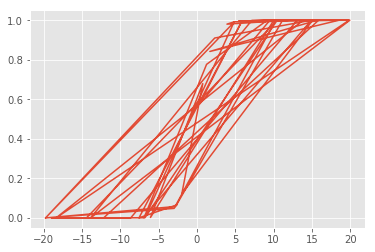

```python
X = np.random.rand(50) * 40 - 20
S = 1 / (1 + np.exp(-X))

plt.plot(X, S)
plt.show()
```

```python
print(X[:3])
print(S[:3])
```

```
[-6.90722793  1.24728695  9.15294426]
[  9.99527431e-04   7.76829866e-01   9.99894104e-01]
```

```python
print(a)
print(a * 2)         # multiplica cada elemento por 2
print(a ** 2)        # exponencial de 2 de cada elemento
print(np.sqrt(a))
```

```
[  1.    2.    3.4   6.    8.    2.   42. ]
[  2.    4.    6.8  12.   16.    4.   84. ]
[  1.00000000e+00   4.00000000e+00   1.15600000e+01   3.60000000e+01
   6.40000000e+01   4.00000000e+00   1.76400000e+03]
[ 1.          1.41421356  1.84390889  2.44948974  2.82842712  1.41421356
  6.4807407 ]
```

```python
a
```

```
array([  1. ,   2. ,   3.4,   6. ,   8. ,   2. ,  42. ])
```

```python
[x * 2 for  x in a]   # Esto es una List Comprehensions es una forma de codigo "natural"
```

```
[2.0, 4.0, 6.7999999999999998, 12.0, 16.0, 4.0, 84.0]
```

```python
[x for x in a if x % 2 == 0]
```

```
[2.0, 6.0, 8.0, 2.0, 42.0]
```